# 概率分布

shixiangzhou

2015年10月4日

# 正态分布

f(x;miu,sigma)=1/(sqrt(2*pi*sigma))*exp{-(x-miu)^2/2*sigma^2}

```
如果装了Latex引擎，就能把公式编的像教科书一样好看。
```

有兴趣的同学可以研究R与latex的连编技巧. [谢益辉](http://yihui.name/knitr/demo/lyx/)，中国人谢益辉编的knitr包. [页面视频帮助](https://www.screenr.com/embed/qcv8)

```r
 #   抽取服从正态分布N(0,1)的随机数
  rnorm(n = 10)
```

```
##  [1] -0.1954209  0.8032858 -0.9329306 -0.7954916  0.0759465  1.5306283
##  [7] -0.7363231 -0.7756331 -0.5203377  1.3967437
```

```r
 # 10 draws from the 100-20 distribution
  rnorm(n = 10, mean = 100, sd = 20)
```

```
##  [1] 111.81487 121.10380  99.84315  74.96859  90.55954  75.55762  93.74410
##  [8]  99.73053 110.04283  99.87284
```

dnorm用于计算正态分布的密度(一个特定值的概率)

```r
   randNorm10 <- rnorm(10)
 randNorm10
```

```
##  [1]  0.80307137 -0.28546831 -0.44786055 -0.06688281 -0.06023256
##  [6] -1.10518782 -1.09877336  2.08068248 -0.80371859  0.35860994
```

```r
   dnorm(randNorm10)
```

```
##  [1] 0.28897926 0.38301367 0.36087340 0.39805098 0.39821926 0.21660961
##  [7] 0.21814616 0.04579601 0.28882904 0.37409740
```

```r
    dnorm(c(-1, 0, 1))
```

```
## [1] 0.2419707 0.3989423 0.2419707
```

```
虽然在技术上我们找到一个来自连续分布的数学上的精确概率，但这是一个概率的估计值，和rnorm命令一样，我们也可以对dnorm命令设置均值和标准差
```

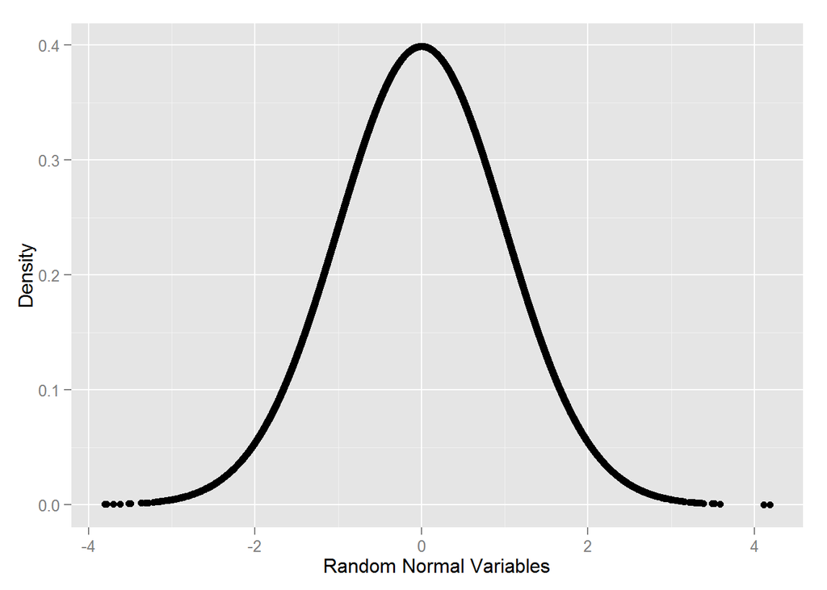

```
pnorm计算正态分布的分布，即给定一个数的累积概率，或小于这个数概率。
```

```r
    randNorm <- rnorm(30000)
  # calcualte their distributions
  randDensity <- dnorm(randNorm)
  # load ggplot2
 require(ggplot2)
  # plot them
  ggplot(data.frame(x = randNorm, y = randDensity)) + aes(x = x, y = y) +geom_point() + labs(x = "Random Normal Variables", y = "Density")
```

```r
   pnorm(randNorm10)
```

```
##  [1] 0.7890333 0.3876427 0.3271269 0.4733375 0.4759852 0.1345391 0.1359335
##  [8] 0.9812685 0.2107798 0.6400565
```

```r
   pnorm(c(-3, 0, 3))
```

```
## [1] 0.001349898 0.500000000 0.998650102
```

```r
    pnorm(-1)#默认为左侧概率
```

```
## [1] 0.1586553
```

```r
     pnorm(1) - pnorm(0)
```

```
## [1] 0.3413447
```

```r
      pnorm(1) - pnorm(-1)
```

```
## [1] 0.6826895
```

```
用面积表示概率:
```

```r
 p <- ggplot(data.frame(x=randNorm, y=randDensity)) + aes(x=x, y=y) +geom_line() + labs(x="x", y="Density")

  neg1Seq <- seq(from=min(randNorm), to=-1, by=.1)
    # build a data.frame of that sequence as x
  # the distribution values for that sequence as y
  lessThanNeg1 <- data.frame(x=neg1Seq, y=dnorm(neg1Seq))

  head(lessThanNeg1)
```

```
##           x            y
## 1 -3.805518 0.0002858841
## 2 -3.705518 0.0004161885
## 3 -3.605518 0.0005998564
## 4 -3.505518 0.0008559758
## 5 -3.405518 0.0012092963
## 6 -3.305518 0.0016914574
```

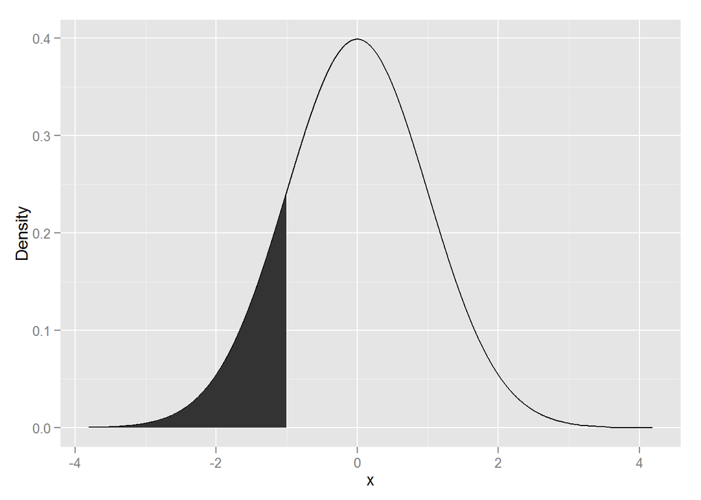

```r
   lessThanNeg1 <- rbind(c(min(randNorm), 0),
                       lessThanNeg1,
                       c(max(lessThanNeg1$x), 0))

  # use that shaded region as a polygon
  p + geom_polygon(data=lessThanNeg1, aes(x=x, y=y))
```

```r
  # create a similar sequence going from -1 to 1
  neg1Pos1Seq <- seq(from=-1, to=1, by=.1)
    # build a data.frame of that sequence as x
  # the distribution values for that sequence as y
  neg1To1 <- data.frame(x=neg1Pos1Seq, y=dnorm(neg1Pos1Seq))

  head(neg1To1)
```

```
##      x         y
## 1 -1.0 0.2419707
## 2 -0.9 0.2660852
## 3 -0.8 0.2896916
## 4 -0.7 0.3122539
## 5 -0.6 0.3332246
## 6 -0.5 0.3520653
```

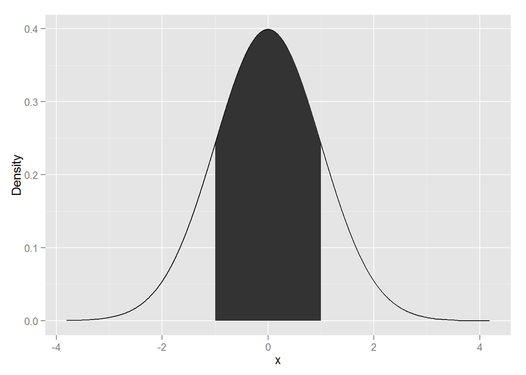

```r
    # combine this with endpoints at the far left and far right
  # the height is 0
  neg1To1 <- rbind(c(min(neg1To1$x), 0),neg1To1,
c(max(neg1To1$x), 0))

  # use that shaded region as a polygon
  p + geom_polygon(data=neg1To1, aes(x=x, y=y))
```

分布函数非递减。

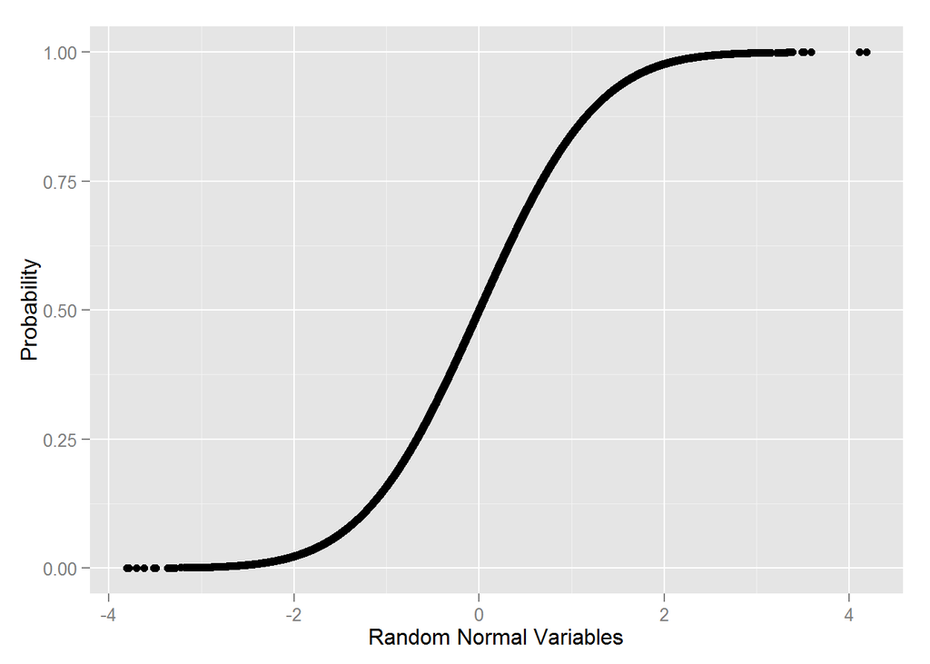

```r
    randProb <- pnorm(randNorm)
  ggplot(data.frame(x=randNorm, y=randProb)) + aes(x=x, y=y) +geom_point() + labs(x="Random Normal Variables", y="Probability")
```

pnorm的对立面是gnorm。

```r
  randNorm10
```

```
##  [1]  0.80307137 -0.28546831 -0.44786055 -0.06688281 -0.06023256
##  [6] -1.10518782 -1.09877336  2.08068248 -0.80371859  0.35860994
```

```r
  qnorm(pnorm(randNorm10))
```

```
##  [1]  0.80307137 -0.28546831 -0.44786055 -0.06688281 -0.06023256
##  [6] -1.10518782 -1.09877336  2.08068248 -0.80371859  0.35860994
```

```r
   all.equal(randNorm10, qnorm(pnorm(randNorm10)))
```

```
## [1] TRUE
```

# 二项分布

公式自己找书看吧。

```r
  #10次试验，每次成功概率为0.4，产生的数是成功的次数
     rbinom(n = 1, size = 10, prob = 0.4)
```

```
## [1] 4
```

```r
    rbinom(n = 1, size = 10, prob = 0.4)
```

```
## [1] 2
```

```r
    rbinom(n = 5, size = 10, prob = 0.4)
```

```
## [1] 4 3 3 5 8
```

```r
      rbinom(n = 10, size = 10, prob = 0.4)
```

```
##  [1] 2 3 4 3 2 5 8 2 3 4
```

```r
      #退化为Bernouli分布的变量
  rbinom(n = 1, size = 1, prob = 0.4)
```

```
## [1] 1
```

```r
    rbinom(n = 5, size = 1, prob = 0.4)
```

```
## [1] 1 1 0 1 1
```

```r
   rbinom(n = 10, size = 1, prob = 0.4)
```

```
##  [1] 1 1 1 0 0 0 0 1 0 0
```

```
 试验10000次，p=0.3,n=10
```

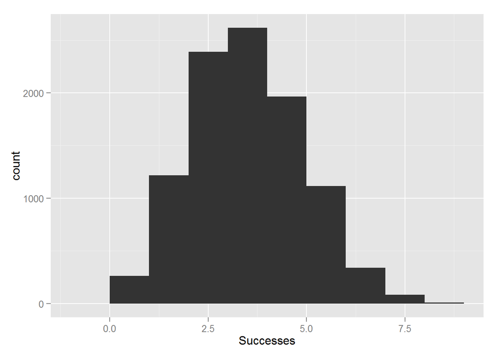

```r
    binomData <- data.frame(Successes = rbinom(n = 10000, size = 10,prob = 0.3))
 ggplot(binomData, aes(x = Successes)) + geom_histogram(binwidth = 1)
```

```r
 binom5 <- data.frame(Successes=rbinom(n=10000, size=5,
prob=.3), Size=5)
dim(binom5)
```

```
## [1] 10000     2
```

```r
 head(binom5)
```

```
##   Successes Size
## 1         2    5
## 2         1    5
## 3         1    5
## 4         3    5
## 5         1    5
## 6         1    5
```

```r
  # similar to before, still 10,000 rows
  # numbers are drawn from a distribution with a different size
  # Size now equals 10 for all 10,000 rows
  binom10 <- data.frame(Successes=rbinom(n=10000, size=10,prob=.3), Size=10)
  dim(binom10)
```

```
## [1] 10000     2
```

```r
  head(binom10)
```

```
##   Successes Size
## 1         3   10
## 2         5   10
## 3         3   10
## 4         4   10
## 5         2   10
## 6         3   10
```

```r
  binom100 <- data.frame(Successes=rbinom(n=10000, size=100,prob=.3), Size=100)

  binom1000 <- data.frame(Successes=rbinom(n=10000, size=1000,prob=.3), Size=1000)

  # combine them all into one data.frame
  binomAll <- rbind(binom5, binom10, binom100, binom1000)
 dim(binomAll)
```

```
## [1] 40000     2
```

```r
  head(binomAll, 10)
```

```
##    Successes Size
## 1          2    5
## 2          1    5
## 3          1    5
## 4          3    5
## 5          1    5
## 6          1    5
## 7          1    5
## 8          1    5
## 9          1    5
## 10         2    5
```

```r
   tail(binomAll, 10)
```

```
##       Successes Size
## 39991       297 1000
## 39992       292 1000
## 39993       294 1000
## 39994       312 1000
## 39995       300 1000
## 39996       293 1000
## 39997       314 1000
## 39998       283 1000
## 39999       321 1000
## 40000       279 1000
```

```
## stat_bin: binwidth defaulted to range/30. Use 'binwidth = x' to adjust this.
## stat_bin: binwidth defaulted to range/30. Use 'binwidth = x' to adjust this.
## stat_bin: binwidth defaulted to range/30. Use 'binwidth = x' to adjust this.
## stat_bin: binwidth defaulted to range/30. Use 'binwidth = x' to adjust this.
```

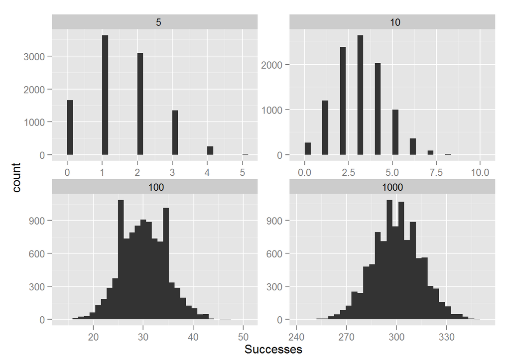

```
给定一个概率值，求分位数，即成功的次数。
```

```r
    # build the plot
  # histograms only need an x aesthetic
 # it is faceted (broken up) based on the values of Size
  # these are 5, 10, 100, 1000
  ggplot(binomAll, aes(x=Successes)) + geom_histogram() +
facet_wrap(~ Size, scales="free")
```

```r
   dbinom(x = 3, size = 10, prob = 0.3)
```

```
## [1] 0.2668279
```

```r
    pbinom(q = 3, size = 10, prob = 0.3)
```

```
## [1] 0.6496107
```

```r
    dbinom(x = 1:10, size = 10, prob = 0.3)
```

```
##  [1] 0.1210608210 0.2334744405 0.2668279320 0.2001209490 0.1029193452
##  [6] 0.0367569090 0.0090016920 0.0014467005 0.0001377810 0.0000059049
```

```r
pbinom(q = 1:10, size = 10, prob = 0.3)
```

```
##  [1] 0.1493083 0.3827828 0.6496107 0.8497317 0.9526510 0.9894079 0.9984096
##  [8] 0.9998563 0.9999941 1.0000000
```

```r
qbinom(p = 0.3, size = 10, prob = 0.3)
```

```
## [1] 2
```

```r
qbinom(p = c(0.3, 0.35, 0.4, 0.5, 0.6), size = 10, prob = 0.3)
```

```
## [1] 2 2 3 3 3
```

# 泊松分布

```r
 pois1 <- rpois(n=10000, lambda=1)
  pois2 <- rpois(n=10000, lambda=2)
  pois5 <- rpois(n=10000, lambda=5)
  pois10 <- rpois(n=10000, lambda=10)
  pois20 <- rpois(n=10000, lambda=20)
  pois <- data.frame(Lambda.1=pois1, Lambda.2=pois2,
  Lambda.5=pois5, Lambda.10=pois10, Lambda.20=pois20)
  # load reshape2 package to melt the data to make it easier to plot
 require(reshape2)
  # melt the data into a long format
  pois <- melt(data=pois, variable.name="Lambda", value.name="x")
  # load the stringr package to help clean up the new column name
  require(stringr)
  # clean up the Lambda to just show the value for that lambda
  #随lambda变化的泊松分布的10 000个样本的直方图，趋向于正态分布
 pois$Lambda <- as.factor(as.numeric(str_extract(string=pois$Lambda,pattern="\\d+")))
  head(pois)
```

```
##   Lambda x
## 1      1 0
## 2      1 0
## 3      1 2
## 4      1 0
## 5      1 0
## 6      1 0
```

```r
 tail(pois)
```

```
##       Lambda  x
## 49995     20 24
## 49996     20 20
## 49997     20 18
## 49998     20 16
## 49999     20 25
## 50000     20 19
```

```
随 lambda变化的泊松分布的10000个样本的密度图，注意趋向于正态分布。
```

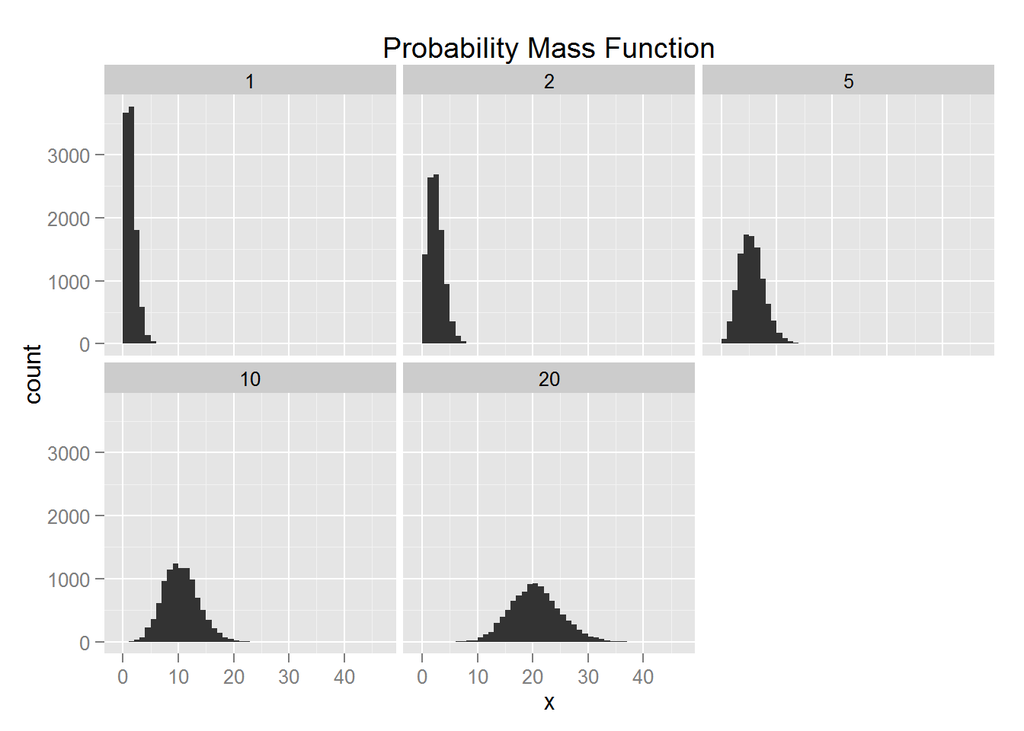

```r
  require(ggplot2)
  ggplot(pois, aes(x=x)) + geom_histogram(binwidth=1) +
 facet_wrap(~ Lambda) + ggtitle("Probability Mass Function")
```

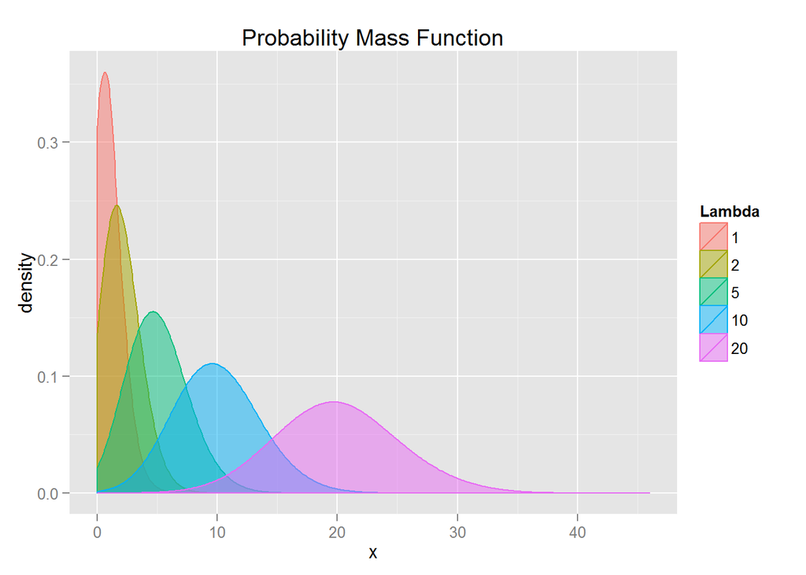

```r
   ggplot(pois, aes(x=x)) +geom_density(aes(group=Lambda, color=Lambda, fill=Lambda),adjust=4, alpha=1/2) +
 scale_color_discrete() + scale_fill_discrete() +
ggtitle("Probability Mass Function")
```

# 描述性统计

```r
  x <- sample(x = 1:100, size = 100, replace = TRUE)
 x
```

```
##   [1]  9 44 32 91 36 45 46 14 79 41 40 33 87 48  6 17 80 74 31 39 92 10 87
##  [24] 74 21 36 49 53 96 80  6 28 35 53 59 73 88 48 95 40 22 32 69  2 61 47
##  [47] 57 67 67 54 47 21 48 54 17 73 91 70 77 13 23 19 68 37 62 63 38 51 47
##  [70] 24 79 31 30 60 69 25 84 63  7 85 90 61 83 70 93 87 67 21  4 98 42 51
##  [93] 99 88 47 37 23  3 94  8
```

```r
  mean(x)
```

```
## [1] 51.35
```

```r
 # copy x
  y <- x
  # choose a random 20 elements, using sample, to set to NA
  y[sample(x = 1:100, size = 20, replace = FALSE)] <- NA
 y
```

```
##   [1]  9 44 32 91 36 45 NA 14 NA 41 40 NA 87 48 NA NA 80 74 31 39 NA NA 87
##  [24] 74 21 36 49 53 96 80  6 28 35 53 59 73 88 48 95 40 22 32 69  2 61 47
##  [47] NA NA NA NA 47 NA NA 54 17 73 91 70 77 NA 23 NA 68 37 62 63 38 51 47
##  [70] NA 79 31 30 60 69 NA 84 63  7 85 90 61 83 70 93 87 67 NA  4 98 42 51
##  [93] NA 88 47 37 23  3 94 NA
```

```r
  mean(y)
```

```
## [1] NA
```

```r
   mean(y, na.rm = TRUE)
```

```
## [1] 54.1125
```

```
计算加权平均
```

```r
    grades <- c(95, 72, 87, 66)
  weights <- c(1/2, 1/4, 1/8, 1/8)
  mean(grades)
```

```
## [1] 80
```

```r
  weighted.mean(x = grades, w = weights)
```

```
## [1] 84.625
```

```r
  var(x)#样本方差
```

```
## [1] 740.1894
```

```r
   sum((x - mean(x))^2)/(length(x) - 1)#计算公式
```

```
## [1] 740.1894
```

```r
    sqrt(var(x))#标准差
```

```
## [1] 27.20642
```

```r
    sd(x)
```

```
## [1] 27.20642
```

```r
     sd(y)#有缺失值的情况
```

```
## [1] NA
```

```r
      sd(y, na.rm = TRUE)
```

```
## [1] 26.25291
```

```
最值函数
```

```r
       min(x)
```

```
## [1] 2
```

```r
      max(x)
```

```
## [1] 99
```

```r
       median(x)
```

```
## [1] 48.5
```

```r
       min(y)
```

```
## [1] NA
```

```r
        min(y, na.rm = TRUE)
```

```
## [1] 2
```

```
功能强大的summery函数可同时计算均值，最小值，最大值，中位数，无需设置参数na.rm，计算统计量时会自动除去缺失值，并对缺失值计数。
```

```r
         summary(x)
```

```
##    Min. 1st Qu.  Median    Mean 3rd Qu.    Max.
##    2.00   31.00   48.50   51.35   73.25   99.00
```

```r
         summary(y)
```

```
##    Min. 1st Qu.  Median    Mean 3rd Qu.    Max.    NA's
##    2.00   36.00   52.00   54.11   74.75   98.00      20
```

```r
  #计算分位数
          quantile(x, probs = c(0.25, 0.75))
```

```
##   25%   75%
## 31.00 73.25
```

```r
          #quantile(y, probs = c(0.25, 0.75))
#Error: missing values and NaN's not allowed if 'na.rm' is FALSE
           quantile(y, probs = c(0.25, 0.75), na.rm = TRUE)
```

```
##   25%   75%
## 36.00 74.75
```

```r
            # compute other quantiles
  quantile(x, probs = c(0.1, 0.25, 0.5, 0.75, 0.99))
```

```
##   10%   25%   50%   75%   99%
## 13.90 31.00 48.50 73.25 98.01
```

## 相关系数和协方差

```r
   require(ggplot2)
   head(economics)#包自带数据集
```

```
##         date   pce    pop psavert uempmed unemploy
## 1 1967-06-30 507.8 198712     9.8     4.5     2944
## 2 1967-07-31 510.9 198911     9.8     4.7     2945
## 3 1967-08-31 516.7 199113     9.0     4.6     2958
## 4 1967-09-30 513.3 199311     9.8     4.9     3143
## 5 1967-10-31 518.5 199498     9.7     4.7     3066
## 6 1967-11-30 526.2 199657     9.4     4.8     3018
```

```r
    cor(economics$pce, economics$psavert)
```

```
## [1] -0.9271222
```

```r
    #pce是个人消费支出，pasavert是个人储蓄率
     # use cor to calculate correlation
 cor(economics$pce, economics$psavert)
```

```
## [1] -0.9271222
```

```r
 #-0.92，说明反向关系
```

```
相关系数的具体计算公式
```

```r
  ## calculate each part of correlation
 xPart <- economics$pce - mean(economics$pce)
  yPart <- economics$psavert - mean(economics$psavert)
  nMinusOne <- (nrow(economics) - 1)
  xSD <- sd(economics$pce)
  ySD <- sd(economics$psavert)
  # use correlation formula
  sum(xPart * yPart) / (nMinusOne * xSD * ySD)
```

```
## [1] -0.9271222
```

```
为比较多个变量，可以对矩阵(数值型变量)用函数cor
```

```r
    cor(economics[, c(2, 4:6)])
```

```
##                 pce     psavert    uempmed    unemploy
## pce       1.0000000 -0.92712221  0.5145862  0.32441514
## psavert  -0.9271222  1.00000000 -0.3615301 -0.07641651
## uempmed   0.5145862 -0.36153012  1.0000000  0.78427918
## unemploy  0.3244151 -0.07641651  0.7842792  1.00000000
```

用图形包GGally可视化数据，加载GGally包会顺带载入reshape包，也会载入namespace和reshape2包，用::直接调用其包内函数。

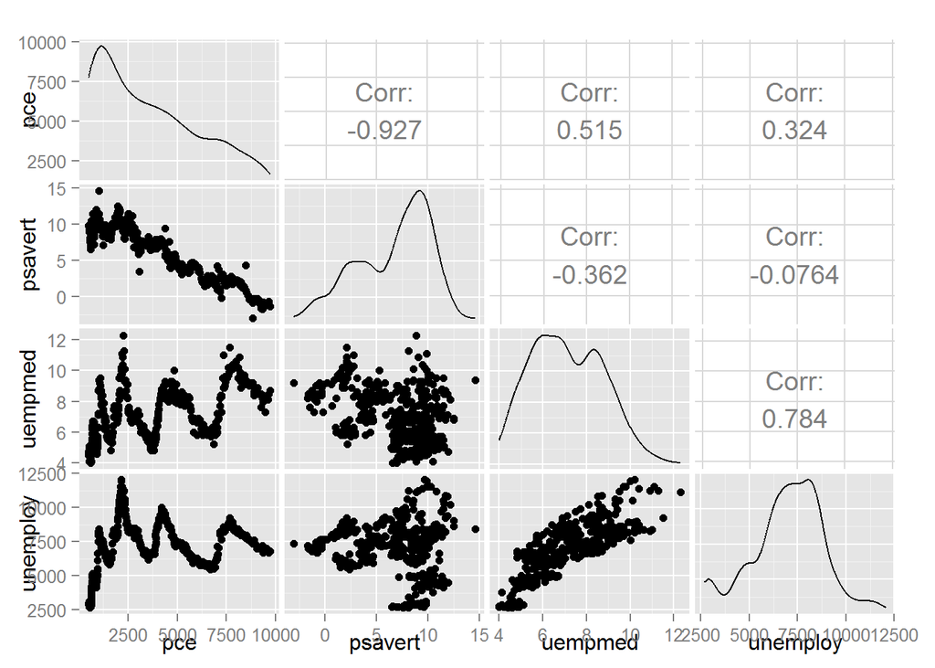

```
类似于多幅散点图，每幅图的x，y轴都不一样，原始数据画的，没有直接明了展现各个变量之间的相关系数，为此绘制热图，较高的正相关系数，意味着两变量有密切的正向关系。
```

```r
   GGally::ggpairs(economics[, c(2, 4:6)], params = list(labelSize = 8))
```

```r
   # 融合数据
  require(reshape2)
  # load the scales package for some extra plotting features
  require(scales)
   # build the correlation matrix
  econCor <- cor(economics[, c(2, 4:6)])
  # melt it into the long format
  econMelt <- melt(econCor, varnames=c("x", "y"),
  value.name="Correlation")
  # 重排
  econMelt <- econMelt[order(econMelt$Correlation), ]
  # 展示数据
  econMelt
```

```
##           x        y Correlation
## 2   psavert      pce -0.92712221
## 5       pce  psavert -0.92712221
## 7   uempmed  psavert -0.36153012
## 10  psavert  uempmed -0.36153012
## 8  unemploy  psavert -0.07641651
## 14  psavert unemploy -0.07641651
## 4  unemploy      pce  0.32441514
## 13      pce unemploy  0.32441514
## 3   uempmed      pce  0.51458618
## 9       pce  uempmed  0.51458618
## 12 unemploy  uempmed  0.78427918
## 15  uempmed unemploy  0.78427918
## 1       pce      pce  1.00000000
## 6   psavert  psavert  1.00000000
## 11  uempmed  uempmed  1.00000000
## 16 unemploy unemploy  1.00000000
```

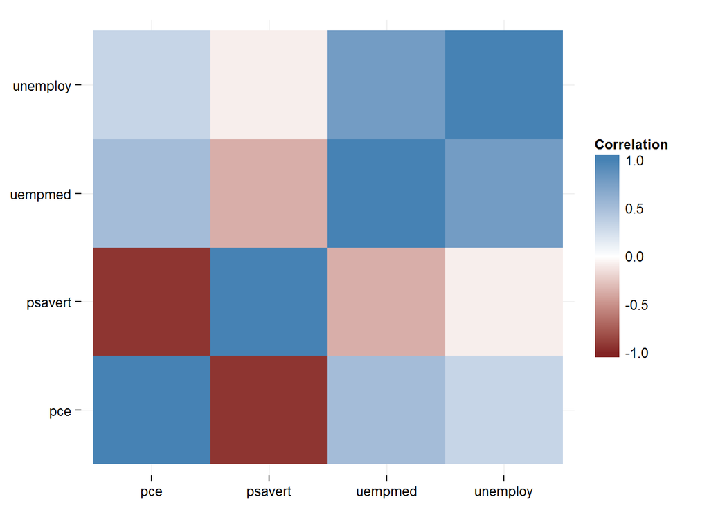

```
cor不用设置参数na.rm来除去缺失值，而是用 "all.obs", "complete.obs","pairwise.complete.obs", "everything" or "na.or.complete"方法计算多个变量的相关系数。
```

```r
ggplot(econMelt, aes(x=x, y=y)) + geom_tile(aes(fill=Correlation)) + scale_fill_gradient2(low=muted("red"), mid="white",
  high="steelblue",
 guide=guide_colorbar(ticks=FALSE, barheight=10),
 limits=c(-1, 1)) +
   # use the minimal theme so there are no extras in the plot
 theme_minimal() +
  # make the x and y labels blank
 labs(x=NULL, y=NULL)
```

### 相关系数

```r
   m <- c(9, 9, NA, 3, NA, 5, 8, 1, 10, 4)
 n <- c(2, NA, 1, 6, 6, 4, 1, 1, 6, 7)
  p <- c(8, 4, 3, 9, 10, NA, 3, NA, 9, 9)
  q <- c(10, 10, 7, 8, 4, 2, 8, 5, 5, 2)
 r <- c(1, 9, 7, 6, 5, 6, 2, 7, 9, 10)
  # 只有第四五列没有缺失值
 theMat <- cbind(m, n, p, q, r)
  cor(theMat, use = "everything")#所有列元素都不能有缺失值
```

```
##    m  n  p          q          r
## m  1 NA NA         NA         NA
## n NA  1 NA         NA         NA
## p NA NA  1         NA         NA
## q NA NA NA  1.0000000 -0.4242958
## r NA NA NA -0.4242958  1.0000000
```

```r
  # cor(theMat, use = "all.obs")
  #all.obs要求所有列都不能含有缺失值
#Error: missing observations in cov/cor
 cor(theMat, use = "complete.obs")
```

```
##            m          n          p          q          r
## m  1.0000000 -0.5228840 -0.2893527  0.2974398 -0.3459470
## n -0.5228840  1.0000000  0.8090195 -0.7448453  0.9350718
## p -0.2893527  0.8090195  1.0000000 -0.3613720  0.6221470
## q  0.2974398 -0.7448453 -0.3613720  1.0000000 -0.9059384
## r -0.3459470  0.9350718  0.6221470 -0.9059384  1.0000000
```

```r
   cor(theMat, use = "na.or.complete")
```

```
##            m          n          p          q          r
## m  1.0000000 -0.5228840 -0.2893527  0.2974398 -0.3459470
## n -0.5228840  1.0000000  0.8090195 -0.7448453  0.9350718
## p -0.2893527  0.8090195  1.0000000 -0.3613720  0.6221470
## q  0.2974398 -0.7448453 -0.3613720  1.0000000 -0.9059384
## r -0.3459470  0.9350718  0.6221470 -0.9059384  1.0000000
```

```r
    cor(theMat[c(1, 4, 7, 9, 10), ])
```

```
##            m          n          p          q          r
## m  1.0000000 -0.5228840 -0.2893527  0.2974398 -0.3459470
## n -0.5228840  1.0000000  0.8090195 -0.7448453  0.9350718
## p -0.2893527  0.8090195  1.0000000 -0.3613720  0.6221470
## q  0.2974398 -0.7448453 -0.3613720  1.0000000 -0.9059384
## r -0.3459470  0.9350718  0.6221470 -0.9059384  1.0000000
```

```r
identical(cor(theMat, use = "complete.obs"),cor(theMat[c(1, 4, 7, 9, 10), ]))
```

```
## [1] TRUE
```

```r
 cor(theMat, use = "pairwise.complete.obs")
```

```
##             m           n          p          q          r
## m  1.00000000 -0.02511812 -0.3965859  0.4622943 -0.2001722
## n -0.02511812  1.00000000  0.8717389 -0.5070416  0.5332259
## p -0.39658588  0.87173889  1.0000000 -0.5197292  0.1312506
## q  0.46229434 -0.50704163 -0.5197292  1.0000000 -0.4242958
## r -0.20017222  0.53322585  0.1312506 -0.4242958  1.0000000
```

```r
   # compare the entries for m vs n to this matrix
  cor(theMat[, c("m", "n")], use = "complete.obs")
```

```
##             m           n
## m  1.00000000 -0.02511812
## n -0.02511812  1.00000000
```

```r
   # compare the entries for m vs p to this matrix
 cor(theMat[, c("m", "p")], use = "complete.obs")
```

```
##            m          p
## m  1.0000000 -0.3965859
## p -0.3965859  1.0000000
```

complete.obs和na.or.complete类似，仅留下不存在缺失值的行。pairwise.complete.obs用途更广，依次比较多对变量，并把两个变量相互之间的缺失列剔除，用余下的数据计算两者的相关系数。

```r
  data(tips, package = "reshape2")
 head(tips)
```

```
##   total_bill  tip    sex smoker day   time size
## 1      16.99 1.01 Female     No Sun Dinner    2
## 2      10.34 1.66   Male     No Sun Dinner    3
## 3      21.01 3.50   Male     No Sun Dinner    3
## 4      23.68 3.31   Male     No Sun Dinner    2
## 5      24.59 3.61 Female     No Sun Dinner    4
## 6      25.29 4.71   Male     No Sun Dinner    4
```

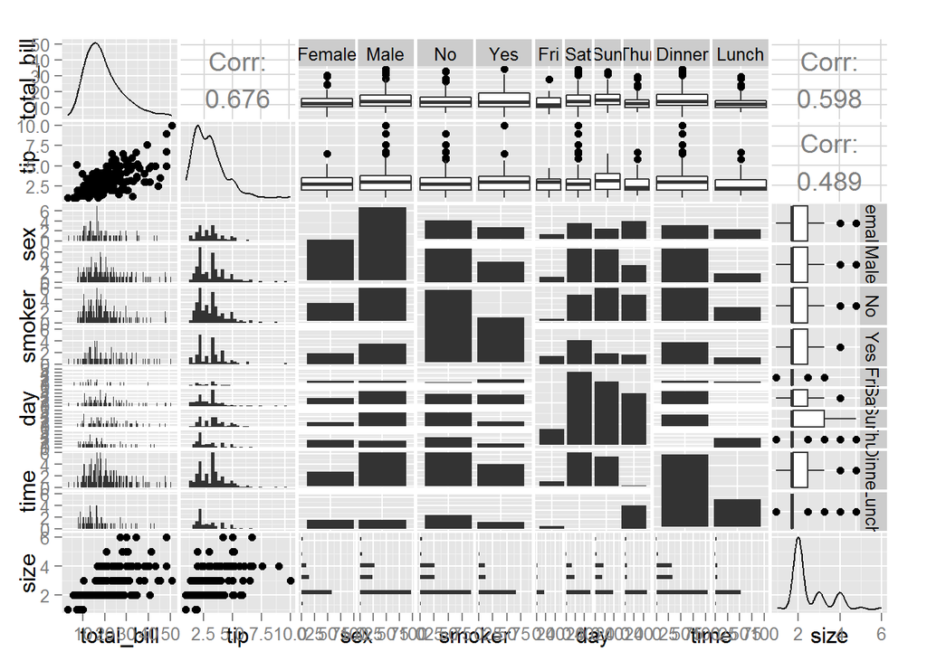

```
相关性并不意味着存在因果关系，也不一定说明它们之间是相互影响的。见XKcd上的第552篇[漫画](http://xkcd.com)。
```

```r
 #根据tips中的连续变量和分类变量的不同，绘制相关变量的直方图，箱线图，散点图
  GGally::ggpairs(tips,params =c(binwidth = 0.3))
```

[figure not shown]

```
## image.url = http://imgs.xkcd.com/comics/correlation.png
## title =  Correlation
## num = 552
## year = 2009
## transcript = [[A man is talking to a woman]]
## Man: I used to think correlation implied causation.
## Man: Then I took a statistics class.  Now I don't.
## Woman: Sounds like the class helped.
## Man: Well, maybe.
## {{Title text: Correlation doesn't imply causation, but it does waggle its eyebrows suggestively and gesture furtively while mouthing 'look over there'.}}
## alt = Correlation doesn't imply causation, but it does waggle its eyebrows suggestively and gesture furtively while mouthing 'look over there'.
```

```
协方差的计算
```

```r
   require(RXKCD)
  getXKCD(which = "552")
```

```r
   cov(economics$pce, economics$psavert)
```

```
## [1] -8412.231
```

```r
  cov(economics[, c(2, 4:6)])
```

```
##                  pce      psavert     uempmed     unemploy
## pce      6810308.380 -8412.230823 2202.786256 1573882.2016
## psavert    -8412.231    12.088756   -2.061893    -493.9304
## uempmed     2202.786    -2.061893    2.690678    2391.6039
## unemploy 1573882.202  -493.930390 2391.603889 3456013.5176
```

```r
   identical(cov(economics$pce, economics$psavert),
  cor(economics$pce, economics$psavert) *
  sd(economics$pce) * sd(economics$psavert))
```

```
## [1] TRUE
```

## t–检验

检验两组数据中平均数是否有显著的差异的检验。

```r
    head(tips)
```

```
##   total_bill  tip    sex smoker day   time size
## 1      16.99 1.01 Female     No Sun Dinner    2
## 2      10.34 1.66   Male     No Sun Dinner    3
## 3      21.01 3.50   Male     No Sun Dinner    3
## 4      23.68 3.31   Male     No Sun Dinner    2
## 5      24.59 3.61 Female     No Sun Dinner    4
## 6      25.29 4.71   Male     No Sun Dinner    4
```

```r
    unique(tips$sex)
```

```
## [1] Female Male
## Levels: Female Male
```

```r
     unique(tips$day)
```

```
## [1] Sun  Sat  Thur Fri
## Levels: Fri Sat Sun Thur
```

```
单样本的t检验。
```

```r
      t.test(tips$tip, alternative = "two.sided", mu = 2.5)
```

```
##
##  One Sample t-test
##
## data:  tips$tip
## t = 5.6253, df = 243, p-value = 5.08e-08
## alternative hypothesis: true mean is not equal to 2.5
## 95 percent confidence interval:
##  2.823799 3.172758
## sample estimates:
## mean of x
##  2.998279
```

```
p值为5.08e-08，说明原假设被拒绝
```

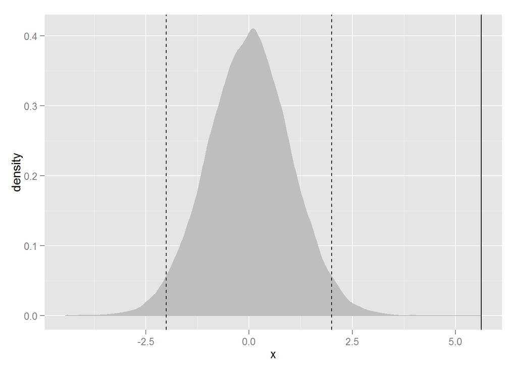

```
p-value 是一个常被误解的概念，尽管所有的误解都认为p值是概率值，且若原假设是正确的，则p值会越小，其实p值是对统计量极端成都的测度，本例中，就是估计均值的极端程度，如果统计量表现太极端，则可以拒绝原假设。

如果确定一个统计量是否为极端的，现代统计之父Ronald A. Fisher引导我们考虑p值是否小于0.10,0.05,0.01，若小于则认为是极端的，由于p值已经成为检验的标准，且被人们任意使用，从而导致一些现代数据科学家质疑其有效性，本例中，p值小于0.01，则我们拒绝原假设。
```

```r
      randT <- rt(30000, df=NROW(tips)-1)

      tipTTest <- t.test(tips$tip, alternative="two.sided", mu=2.50)

       ggplot(data.frame(x=randT)) +
  geom_density(aes(x=x), fill="grey", color="grey") +
 geom_vline(xintercept=tipTTest$statistic) +
 geom_vline(xintercept=mean(randT) + c(-2, 2)*sd(randT), linetype=2)
```

```r
       t.test(tips$tip, alternative = "greater", mu = 2.5)
```

```
##
##  One Sample t-test
##
## data:  tips$tip
## t = 5.6253, df = 243, p-value = 2.54e-08
## alternative hypothesis: true mean is greater than 2.5
## 95 percent confidence interval:
##  2.852023      Inf
## sample estimates:
## mean of x
##  2.998279
```

```
自由度，贯穿整个统计学，代表观测值的有效数量，一般，自由度是某些统计量或分布的观测值的数目减去它要估计的参数数量。
t分布只需估计标准差这个参数，自由度nrow(tips)-1=243(本例)

拒绝原假设得到均值是大于2.50的结论，和统计量在置信区间之外相当符合。
```

### 两样本的t–检验

问变量tip在男女之间是否有差异。

```r
       #按性别每个组的数量
       aggregate(tip ~ sex, data=tips, var)
```

```
##      sex      tip
## 1 Female 1.344428
## 2   Male 2.217424
```

```r
       #检验正态性
        shapiro.test(tips$tip)
```

```
##
##  Shapiro-Wilk normality test
##
## data:  tips$tip
## W = 0.89781, p-value = 8.2e-12
```

```r
         shapiro.test(tips$tip[tips$sex == "Female"])
```

```
##
##  Shapiro-Wilk normality test
##
## data:  tips$tip[tips$sex == "Female"]
## W = 0.95678, p-value = 0.005448
```

```r
          shapiro.test(tips$tip[tips$sex == "Male"])
```

```
##
##  Shapiro-Wilk normality test
##
## data:  tips$tip[tips$sex == "Male"]
## W = 0.87587, p-value = 3.708e-10
```

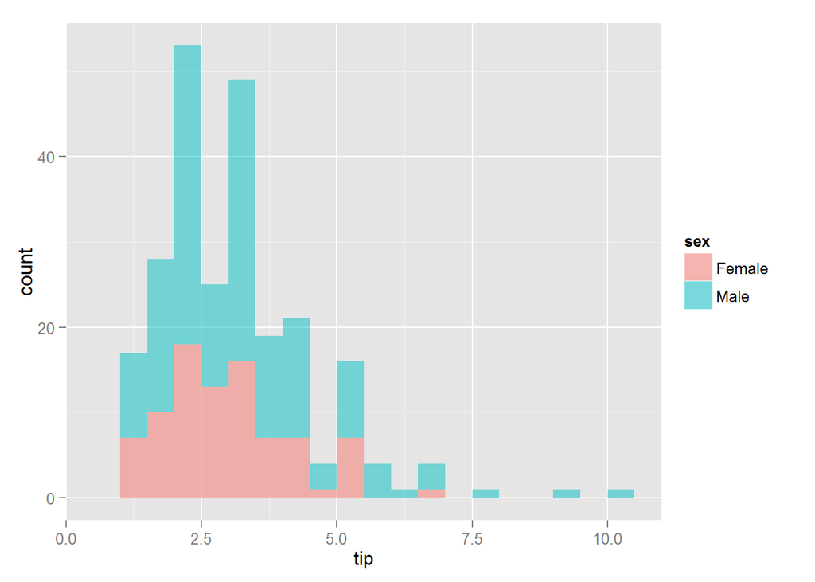

```r
      #检验结果表明不服从正态分布
           ggplot(tips, aes(x=tip, fill=sex)) +
  geom_histogram(binwidth=.5, alpha=1/2)
```

用非参数 Ansari-Bradley 检验两者方差是否相等。

```r
            ansari.test(tip ~ sex, tips)
```

```
##
##  Ansari-Bradley test
##
## data:  tip by sex
## AB = 5582.5, p-value = 0.376
## alternative hypothesis: true ratio of scales is not equal to 1
```

表明两者方差是相等的，可以用标准的两样本t-检验

```r
    t.test(tip ~ sex, data = tips, var.equal = TRUE)
```

```
##
##  Two Sample t-test
##
## data:  tip by sex
## t = -1.3879, df = 242, p-value = 0.1665
## alternative hypothesis: true difference in means is not equal to 0
## 95 percent confidence interval:
##  -0.6197558  0.1074167
## sample estimates:
## mean in group Female   mean in group Male
##             2.833448             3.089618
```

p值不显著，表明男女工人被给小费tip大体相等。

```
用经验法则判断两者是否相等
```

```r
            require(plyr)
  tipSummary <- ddply(tips, "sex", summarize,
  tip.mean=mean(tip), tip.sd=sd(tip),
 Lower=tip.mean - 2*tip.sd/sqrt(NROW(tip)),
  Upper=tip.mean + 2*tip.sd/sqrt(NROW(tip)))
  tipSummary
```

```
##      sex tip.mean   tip.sd    Lower    Upper
## 1 Female 2.833448 1.159495 2.584827 3.082070
## 2   Male 3.089618 1.489102 2.851931 3.327304
```

根据分类变量sex用函数ddply对数据进行分类，把summarise函数运用到子集数据上，返回一个数据框。

```
可视化：两样本的置信区间有重叠。
```

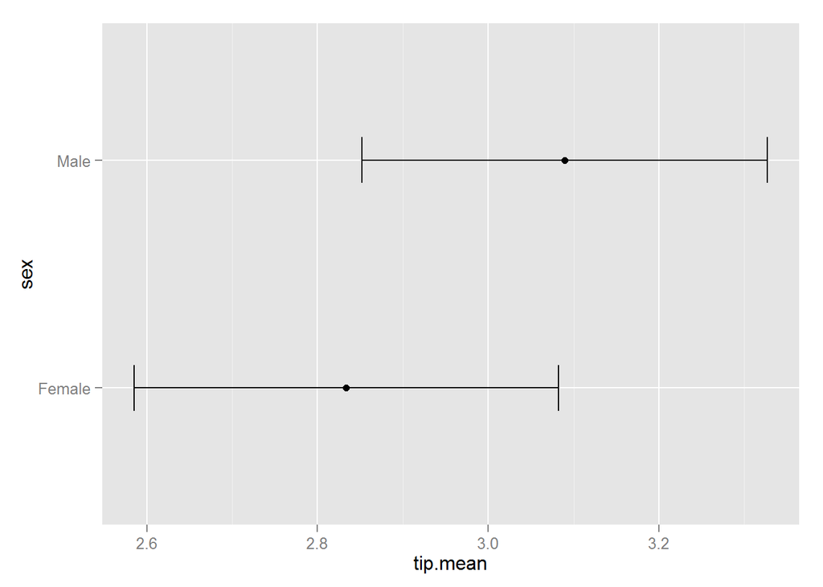

```r
   ggplot(tipSummary, aes(x=tip.mean, y=sex)) + geom_point() +
 geom_errorbarh(aes(xmin=Lower, xmax=Upper), height=.2)
```

### 两配对样本的t–检验

双胞胎测度，治疗前后差异，父亲和儿子的比较，差异性

```r
   require(UsingR)
 head(father.son)
```

```
##    fheight  sheight
## 1 65.04851 59.77827
## 2 63.25094 63.21404
## 3 64.95532 63.34242
## 4 65.75250 62.79238
## 5 61.13723 64.28113
## 6 63.02254 64.24221
```

```r
  t.test(father.son$fheight, father.son$sheight, paired = TRUE)
```

```
##
##  Paired t-test
##
## data:  father.son$fheight and father.son$sheight
## t = -11.789, df = 1077, p-value < 2.2e-16
## alternative hypothesis: true difference in means is not equal to 0
## 95 percent confidence interval:
##  -1.1629160 -0.8310296
## sample estimates:
## mean of the differences
##              -0.9969728
```

结果表明应拒绝原假设，认为父亲和儿子有不同的身高。

```
可以画出父亲与儿子身高差的核密度曲线
```

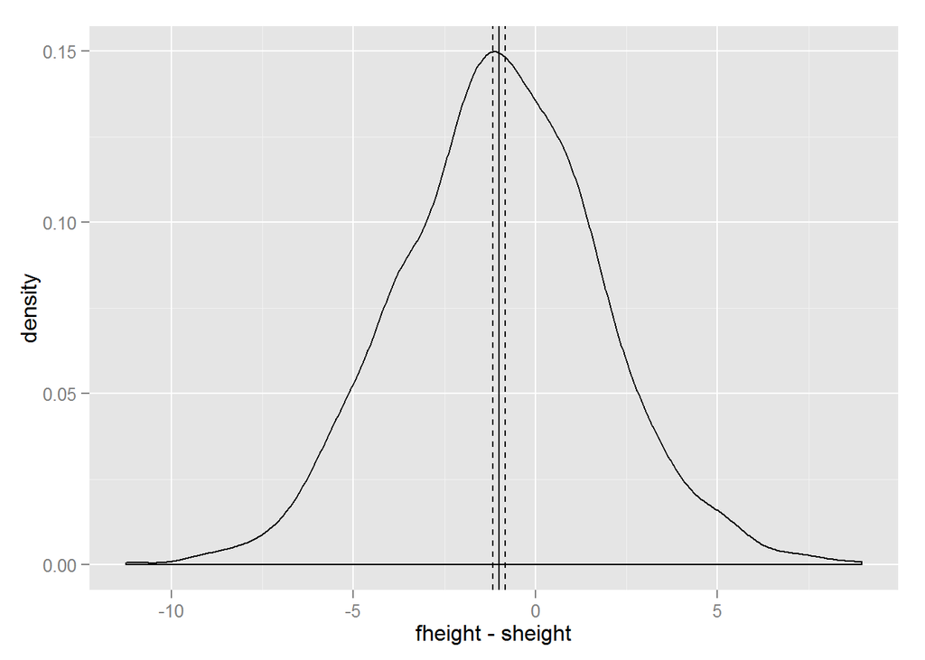

```r
   heightDiff <- father.son$fheight - father.son$sheight
  ggplot(father.son, aes(x=fheight - sheight)) +
 geom_density() +
 geom_vline(xintercept=mean(heightDiff)) +
 geom_vline(xintercept=mean(heightDiff) +
 2*c(-1, 1)*sd(heightDiff)/sqrt(nrow(father.son)),
 linetype=2)
```

如有错误请联系 [e-mail]:shixiangbupt@qq.com.